# DL_ch06

```python
import pandas as pd
import numpy as np
import matplotlib.pyplot as plt
%matplotlib inline
```

## 6.3. Hidden Units

Relu 는 z=0 에서 미분 불가능하지만, 좌극한은 0, 우극한은 1 이므로, 어쨋든 구현된 SW는 값을 내어 놓는다.

### 6.3.1. Rectified Linear Units and Their Generalizations

g$(z) = max\{0,z\} $

leaky Relu $ h_i = g(z,\alpha)_i = max(0, z_i) + \alpha_imin(0,z_i) $

### 6.3.2. Logistic Sigmoid and Hyperbolic Tangent

g$ (z) = \sigma(z)$

g$ (z) = \tanh(z)$

$ tanh(z) = 2\sigma(2z) - 1 $

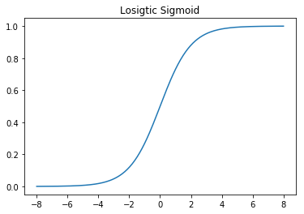

```python
x = np.linspace(-8, 8, 200)
y = np.exp(x) / (np.exp(x) + 1)
plt.plot(x, y)
plt.title("Losigtic Sigmoid")
plt.show()
```

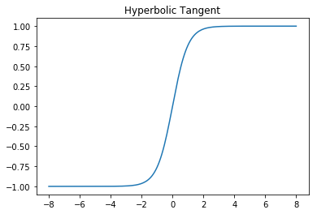

```python
x = np.linspace(-8, 8, 200)
y = np.tanh(x)
plt.plot(x, y)
plt.title("Hyperbolic Tangent")
plt.show()
```

### 6.3.3. Other Hidden Units

### Softplus (for the conditional distributions of undirected probabilistic models), but empirically it does not work well

g$ (z) = \zeta(z) = log (1 + e^z)$

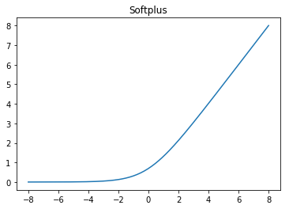

```python
x = np.linspace(-8, 8, 200)
y = np.log(1+np.exp(x))
plt.plot(x, y)
plt.title("Softplus")
plt.show()
```

#### 6.4.1 Universal Approximation Properties and Depth

universal approximation theorem

- regardless of what function we are trying to learn, we know that a large MLP will be able to represent this function
- However, we are not guaranteed that the training algorithm will be able to learn that function

we can interpret the use of a deep architecture as expressing a belief that the function we want to learn is a computer program consisting of multiple steps, where each step makes use of the previous step’s output

Empirically, greater depth does seem to result in better generalization for a wide variety of tasks

### 6.5 Back-Propagation and Other Differentiation Algorithm

The back-propagation algorithm allows the information from the cost to then ﬂow backwards through the network, in order to compute the gradient.

- compute the gradient : $ \nabla_x f(x,y) $
- In learning Algorithm $ \nabla_\theta J(\theta)$

#### 6.5.2. Chain Rule of Calculus

$ \cfrac{dz}{dx} = \cfrac{dz}{dy}\cfrac{dy}{dx} $

$ \nabla_x z = \left(\cfrac{\partial y}{\partial x}\right)^T \nabla_y z $

back-propagation is still just multiplying Jacobians by gradients.

- 우리는 z가 scalar 인 한에서 논의함

#### 6.5.3 Recursively Applying the Chain Rule to Obtain Backprop

$ \cfrac{\partial u^{(n)}}{\partial u^{(i)}} $

#### 6.5.5 Symbol-to-Symbol Derivatives

- Symbol-to-Number
- Symbol-to-Symbol

### 6.6. Historical Notes

- chain rule : inveted (1676)
- grandient descent : used for approximation and optimzation (1847, Cauchy)
- approximation tech : perceptron (1940)

#### loss function

- mean squared error : popular (1980s~1990s)
- (1990s~) cross-entropy and MLE (with sigomid and softmax output)

#### Relu (Rectified linear unit)

- first used (1975)
- (2000s) avoided due to a somewhat superstitious belief that activation functions with non-diﬀerentiable points must be avoided.
- (2009) using a rectifying nonlinearity is the single most important factor in improving the performance of a recognition system

#### FFN

- (2006-2012) believed that feedforward networks would not perform well
- Today, it is now known that with the right resources and engineering practices, feedforward networks perform very well.
- Today, gradient-based learning in feedforward networks is used as a tool to develop probabilistic models

#### unsupervised learning

- (2006) used unsupervised learning to support supervised learning
- now, ironically, it is more common to use supervised learning to support unsupervised learning.